# rel_ipca

rel_author

2025-11-08

### Relatório 1 - Resultados recentes de inflação (IPCA)

#### Pergunta-Chave

Como a inflação (IPCA) acumulada em 12 meses se comportou no Brasil nos últimos 2 anos? Conseguimos ver os picos recentes e a tendência atual?

#### Descrição dos Dados

Usaremos os dados diretamente do IBGE. Pela página SIDRA. https://sidra.ibge.gov.br/.

O dado é a tabela 1737, que contém o número índice do IPCA (Índice Nacional de Preços ao Consumidor Amplo), que é a medida oficial de inflação no Brasil. https://sidra.ibge.gov.br/. Outra forma de consumir esse dado seria pelo pacote em R, chamado *sidrar*, informações sobre o pacote estão disponíveis em: https://cran.r-project.org/web/packages/sidrar/index.html

Vamos mostrar os códigos e os resultados. Para esconder os códigos do resultado, colocar *echo = FALSE*. Observar primeiro bloco de código abaixo com essa propriedade inserida.

Bloco de código 1. Carregamento de pacotes (omitido)

Bloco de código 2. Carregamento de dados

```r
# 2. Carga de dados - arquivo no Temp

#### ajustar caminho da pasta - EXEMPLO: '/cloud/project/'

dados_brutos_ipca <- readxl::read_excel('C:/mark/projetos/oficina_r_mackrio/Tabela1737.xlsx',
                                        col_types = "text")
# observar dados parciais para identificar dados baixados
dplyr::tibble(head(dados_brutos_ipca))
```

```
## # A tibble: 6 × 2
##   Tabela 1737 - IPCA - Série histórica com número-índice, variação mensa…¹ ...2
##   <chr>                                                                    <chr>
## 1 Variável - IPCA - Variação acumulada em 12 meses (%)                     <NA>
## 2 Brasil                                                                   <NA>
## 3 Mês                                                                      <NA>
## 4 202310                                                                   4.82
## 5 202311                                                                   4.68
## 6 202312                                                                   4.62
## # ℹ abbreviated name:
## #   ¹`Tabela 1737 - IPCA - Série histórica com número-índice, variação mensal e variações acumuladas em 3 meses, em 6 meses, no ano e em 12 meses (a partir de dezembro/1979)`
```

Bloco de código 3. Limpeza de dados

```r
# 3. Limpeza dos Dados
# Os dados do SIDRA vêm com muitas colunas. Vamos selecionar e renomear.
dados_tratados_ipca <- dados_brutos_ipca %>%
  slice(-c(1:3,n())) %>%
  rename(ano_mes = 1,valor = 2) %>%
  # Converter a string "202304" para um formato de data real
  # ym() do lubridate entende "AnoMês"
  mutate(data = ym(ano_mes)) %>%
  # Garantir que o valor é numérico (às vezes vem como character)
  mutate(valor = as.numeric(valor)) %>%
  # Remover qualquer linha que não tenha data ou valor
  filter(!is.na(data), !is.na(valor)) %>%
  # Ordenar pela data, essencial para cálculos de série temporal
  arrange(data)

# observar dados prontos
dplyr::tibble(head(dados_tratados_ipca))
```

```
## # A tibble: 6 × 3
##   ano_mes valor data
##   <chr>   <dbl> <date>
## 1 202310   4.82 2023-10-01
## 2 202311   4.68 2023-11-01
## 3 202312   4.62 2023-12-01
## 4 202401   4.51 2024-01-01
## 5 202402   4.5  2024-02-01
## 6 202403   3.93 2024-03-01
```

Bloco de código 4. Visualização inicial

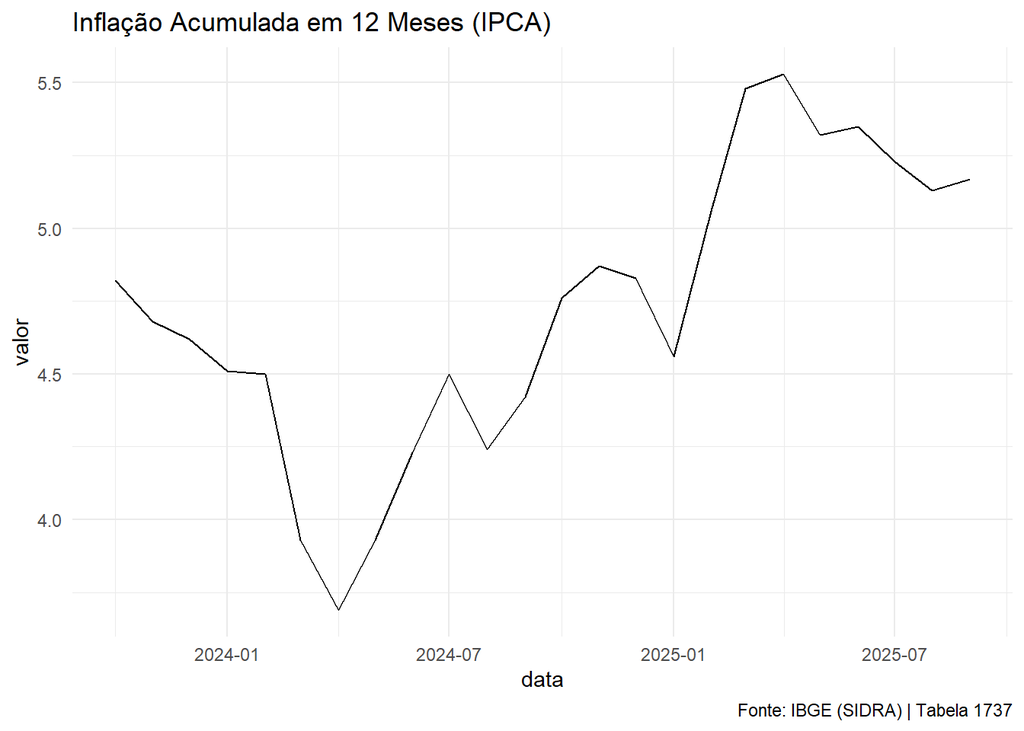

```r
# 5. Visualização dos Resultados

ggplot(dados_tratados_ipca, aes(x = data, y = valor)) +
  geom_line() +
  labs(
    title = "Inflação Acumulada em 12 Meses (IPCA)",
    caption = "Fonte: IBGE (SIDRA) | Tabela 1737"
  ) +
  theme_minimal()
```

Bloco de código 5. Visualização para análise

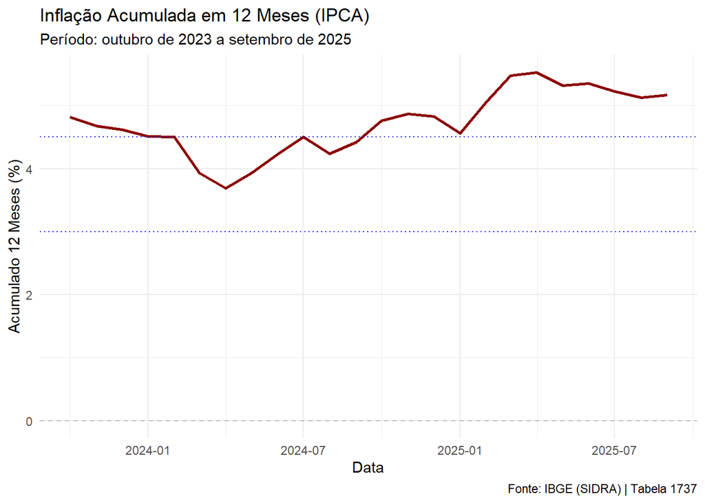

```r
# 5. Visualização dos Resultados

ggplot(dados_tratados_ipca, aes(x = data, y = valor)) +
  geom_line(color = "darkred", linewidth = 1) +
  geom_hline(yintercept = 0, linetype = "dashed", color = "gray") +
  # Adicionar linhas de meta de inflação (ex: 3% e 4.5%)
  geom_hline(yintercept = 3.0, linetype = "dotted", color = "blue") +
  geom_hline(yintercept = 4.5, linetype = "dotted", color = "blue") +
  labs(
    title = "Inflação Acumulada em 12 Meses (IPCA)",
    subtitle = "Período: outubro de 2023 a setembro de 2025",
    y = "Acumulado 12 Meses (%)",
    x = "Data",
    caption = "Fonte: IBGE (SIDRA) | Tabela 1737"
  ) +
  theme_minimal()
```

#### Análise Básica dos Resultados

O gráfico de linhas mostra a trajetória da inflação acumulada. Os participantes poderão identificar o valor um pouco acima de $5\%$ para o ano de 2025. Com o máximo de $5,53\%$ em Abril de 2025. As linhas pontilhadas ajudam a comparar o resultado com as metas de inflação (que podem ser ajustadas no código), permitindo uma discussão sobre política monetária (Selic) e o custo de vida no período.